# Data Preparation

## Data exploration and Visualization

```python
import pandas as pd
import numpy as np

TrainImages = pd.read_csv(r"csvTrainImages 13440x1024.csv", header=None)
TrainLabels = pd.read_csv(r"csvTrainLabel 13440x1.csv", header=None)
TestImages  = pd.read_csv(r"csvTestImages 3360x1024.csv", header=None)
TestLabels  = pd.read_csv(r"csvTestLabel 3360x1.csv", header=None)

TrainImages
```

|  | 0 | 1 | 2 | 3 | 4 | 5 | 6 | 7 | 8 | 9 | ... | 1014 | 1015 | 1016 | 1017 | 1018 | 1019 | 1020 | 1021 | 1022 | 1023 |
| --- | --- | --- | --- | --- | --- | --- | --- | --- | --- | --- | --- | --- | --- | --- | --- | --- | --- | --- | --- | --- | --- |
| 0 | 0 | 0 | 0 | 0 | 0 | 0 | 0 | 0 | 0 | 0 | ... | 0 | 0 | 0 | 0 | 0 | 0 | 0 | 0 | 0 | 0 |
| 1 | 0 | 0 | 0 | 0 | 0 | 0 | 0 | 0 | 0 | 0 | ... | 0 | 0 | 0 | 0 | 0 | 0 | 0 | 0 | 0 | 0 |
| 2 | 0 | 0 | 0 | 0 | 0 | 0 | 0 | 0 | 0 | 0 | ... | 0 | 0 | 0 | 0 | 0 | 0 | 0 | 0 | 0 | 0 |
| 3 | 0 | 0 | 0 | 0 | 0 | 0 | 0 | 0 | 0 | 0 | ... | 0 | 0 | 0 | 0 | 0 | 0 | 0 | 0 | 0 | 0 |
| 4 | 0 | 0 | 0 | 0 | 0 | 0 | 0 | 0 | 0 | 0 | ... | 0 | 0 | 0 | 0 | 0 | 0 | 0 | 0 | 0 | 0 |
| ... | ... | ... | ... | ... | ... | ... | ... | ... | ... | ... | ... | ... | ... | ... | ... | ... | ... | ... | ... | ... | ... |
| 13435 | 0 | 0 | 0 | 0 | 0 | 0 | 0 | 0 | 0 | 0 | ... | 0 | 0 | 0 | 0 | 0 | 0 | 0 | 0 | 0 | 0 |
| 13436 | 0 | 0 | 0 | 0 | 0 | 0 | 0 | 0 | 0 | 0 | ... | 0 | 0 | 0 | 0 | 0 | 0 | 0 | 0 | 0 | 0 |
| 13437 | 0 | 0 | 0 | 0 | 0 | 0 | 0 | 0 | 0 | 0 | ... | 0 | 0 | 0 | 0 | 0 | 0 | 0 | 0 | 0 | 0 |
| 13438 | 0 | 0 | 0 | 0 | 0 | 0 | 0 | 0 | 0 | 0 | ... | 0 | 0 | 0 | 0 | 0 | 0 | 0 | 0 | 0 | 0 |
| 13439 | 0 | 0 | 0 | 0 | 0 | 0 | 0 | 0 | 0 | 0 | ... | 0 | 0 | 0 | 0 | 0 | 0 | 0 | 0 | 0 | 0 |

13440 rows × 1024 columns

```python
TrainLabels
```

|  | 0 |
| --- | --- |
| 0 | 1 |
| 1 | 1 |
| 2 | 1 |
| 3 | 1 |
| 4 | 1 |
| ... | ... |
| 13435 | 28 |
| 13436 | 28 |
| 13437 | 28 |
| 13438 | 28 |
| 13439 | 28 |

13440 rows × 1 columns

```python
TestImages
```

|  | 0 | 1 | 2 | 3 | 4 | 5 | 6 | 7 | 8 | 9 | ... | 1014 | 1015 | 1016 | 1017 | 1018 | 1019 | 1020 | 1021 | 1022 | 1023 |
| --- | --- | --- | --- | --- | --- | --- | --- | --- | --- | --- | --- | --- | --- | --- | --- | --- | --- | --- | --- | --- | --- |
| 0 | 0 | 0 | 0 | 0 | 0 | 0 | 0 | 0 | 0 | 0 | ... | 0 | 0 | 0 | 0 | 0 | 0 | 0 | 0 | 0 | 0 |
| 1 | 0 | 0 | 0 | 0 | 0 | 0 | 0 | 0 | 0 | 0 | ... | 0 | 0 | 0 | 0 | 0 | 0 | 0 | 0 | 0 | 0 |
| 2 | 0 | 0 | 0 | 0 | 0 | 0 | 0 | 0 | 0 | 0 | ... | 0 | 0 | 0 | 0 | 0 | 0 | 0 | 0 | 0 | 0 |
| 3 | 0 | 0 | 0 | 0 | 0 | 0 | 0 | 0 | 0 | 0 | ... | 0 | 0 | 0 | 0 | 0 | 0 | 0 | 0 | 0 | 0 |
| 4 | 0 | 0 | 0 | 0 | 0 | 0 | 0 | 0 | 0 | 0 | ... | 0 | 0 | 0 | 0 | 0 | 0 | 0 | 0 | 0 | 0 |
| ... | ... | ... | ... | ... | ... | ... | ... | ... | ... | ... | ... | ... | ... | ... | ... | ... | ... | ... | ... | ... | ... |
| 3355 | 0 | 0 | 0 | 0 | 0 | 0 | 0 | 0 | 0 | 0 | ... | 0 | 0 | 0 | 0 | 0 | 0 | 0 | 0 | 0 | 0 |
| 3356 | 0 | 0 | 0 | 0 | 0 | 0 | 0 | 0 | 0 | 0 | ... | 0 | 0 | 0 | 0 | 0 | 0 | 0 | 0 | 0 | 0 |
| 3357 | 0 | 0 | 0 | 0 | 0 | 0 | 0 | 0 | 0 | 0 | ... | 0 | 0 | 0 | 0 | 0 | 0 | 0 | 0 | 0 | 0 |
| 3358 | 0 | 0 | 0 | 0 | 0 | 0 | 0 | 0 | 0 | 0 | ... | 0 | 0 | 0 | 0 | 0 | 0 | 0 | 0 | 0 | 0 |
| 3359 | 0 | 0 | 0 | 0 | 0 | 0 | 0 | 0 | 0 | 0 | ... | 0 | 0 | 0 | 0 | 0 | 0 | 0 | 0 | 0 | 0 |

3360 rows × 1024 columns

```python
TestLabels
```

|  | 0 |
| --- | --- |
| 0 | 1 |
| 1 | 1 |
| 2 | 2 |
| 3 | 2 |
| 4 | 3 |
| ... | ... |
| 3355 | 26 |
| 3356 | 27 |
| 3357 | 27 |
| 3358 | 28 |
| 3359 | 28 |

3360 rows × 1 columns

```python
print(f"Train Iamges Shape : {TrainImages.shape}")
print(f"Test  Iamges Shape : {TestLabels.shape}")
print(f"Train Labels Shape : {TestImages.shape}")
print(f"Test  Labels Shape : {TestLabels.shape}")
```

```
Train Iamges Shape : (13440, 1024)
Test  Iamges Shape : (3360, 1)
Train Labels Shape : (3360, 1024)
Test  Labels Shape : (3360, 1)
```

```python
TrainImages.info()
```

```
<class 'pandas.core.frame.DataFrame'>
RangeIndex: 13440 entries, 0 to 13439
Columns: 1024 entries, 0 to 1023
dtypes: int64(1024)
memory usage: 105.0 MB
```

```python
TrainLabels.info()
```

```
<class 'pandas.core.frame.DataFrame'>
RangeIndex: 13440 entries, 0 to 13439
Data columns (total 1 columns):
 #   Column  Non-Null Count  Dtype
---  ------  --------------  -----
 0   0       13440 non-null  int64
dtypes: int64(1)
memory usage: 105.1 KB
```

```python
TestImages.info()
```

```
<class 'pandas.core.frame.DataFrame'>
RangeIndex: 3360 entries, 0 to 3359
Columns: 1024 entries, 0 to 1023
dtypes: int64(1024)
memory usage: 26.3 MB
```

```python
TestLabels.info()
```

```
<class 'pandas.core.frame.DataFrame'>
RangeIndex: 3360 entries, 0 to 3359
Data columns (total 1 columns):
 #   Column  Non-Null Count  Dtype
---  ------  --------------  -----
 0   0       3360 non-null   int64
dtypes: int64(1)
memory usage: 26.4 KB
```

See how many classes we got:

```python
print(f"Number of Classes:", TrainLabels.nunique())
```

```
Number of Classes: 0    28
dtype: int64
```

Check the data balancing for each class:

```
<BarContainer object of 28 artists>
```

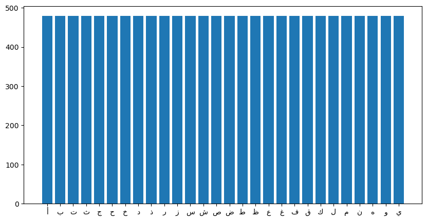

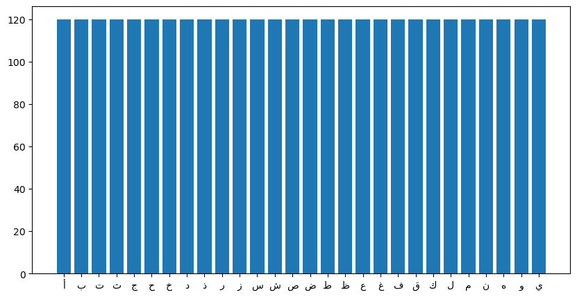

```python
import matplotlib.pyplot as plt

numeric_arabic = {
    1: 'أ', 2: 'ب', 3: 'ت', 4: 'ث', 5: 'ج',
    6: 'ح', 7: 'خ', 8: 'د', 9: 'ذ', 10: 'ر',
    11: 'ز', 12: 'س', 13: 'ش', 14: 'ص', 15: 'ض',
    16: 'ط', 17: 'ظ', 18: 'ع', 19: 'غ', 20: 'ف',
    21: 'ق', 22: 'ك', 23: 'ل', 24: 'م', 25: 'ن',
    26: 'ه', 27: 'و', 28: 'ي'
}
plt.figure(figsize=(10, 5))
plt.bar([numeric_arabic[x] for x in range(1,29)], TrainLabels.value_counts())

plt.figure(figsize=(10, 5))
plt.bar([numeric_arabic[x] for x in range(1,29)], TestLabels.value_counts())
```

Make the Labels range from [0,27] instead of [1,28]:

```python
x_train = TrainImages.to_numpy()
y_train = TrainLabels.to_numpy() -1
x_test = TestImages.to_numpy()
y_test = TestLabels.to_numpy() -1

print(f"X_Train Shape : {x_train.shape}")
print(f"Y_Train Shape : {y_train.shape}")
print(f"X_Test  Shape : {x_test.shape}")
print(f"Y_Test  Shape : {y_test.shape}")

x_train.max(), x_train.min(), y_train.max(), y_train.min()
```

```
X_Train Shape : (13440, 1024)
Y_Train Shape : (13440, 1)
X_Test  Shape : (3360, 1024)
Y_Test  Shape : (3360, 1)
```

```
(255, 0, 27, 0)
```

Plot one character:

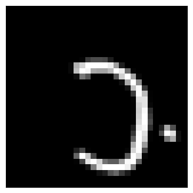

```python
plt.figure(figsize=(4, 4),)
plt.xticks([])
plt.yticks([])
plt.imshow(x_train[10].reshape(32,32), "gray")
plt.subplots_adjust(wspace=0.01, hspace=0.01)
plt.show()
```

Toggel each image matrix in the Train and Test datasets make the data correct:

```python
x_train = np.array([i.reshape(32, 32).T for i in x_train])
x_test = np.array([i.reshape(32, 32).T for i in x_test])
```

See the first 400 images:

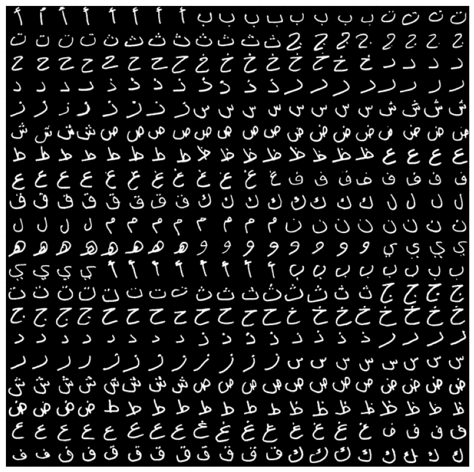

```python
plt.figure(figsize=(10, 10),)
for i in range(400):
    plt.subplot(20, 20, i + 1)
    plt.xticks([])
    plt.yticks([])
    plt.imshow(x_train[i], "gray")
plt.subplots_adjust(wspace=0.01, hspace=0.01)
plt.show()
```

## Data Preprocessing

Shuffling and Scaling the data:

```python
rng = np.random.default_rng(42) # seed = 42 to always get the same random numbers
shuffled_indices_train = rng.permutation(len(TrainImages))

x_train = x_train[shuffled_indices_train]
y_train = y_train[shuffled_indices_train]

x_train = x_train / 255.0
x_test  = x_test  / 255.0

y_train = y_train.flatten()
y_test = y_test.flatten()
```

```python
x_train.shape, y_train.shape
```

```
((13440, 32, 32), (13440,))
```

See the first 400 images after shuffling:

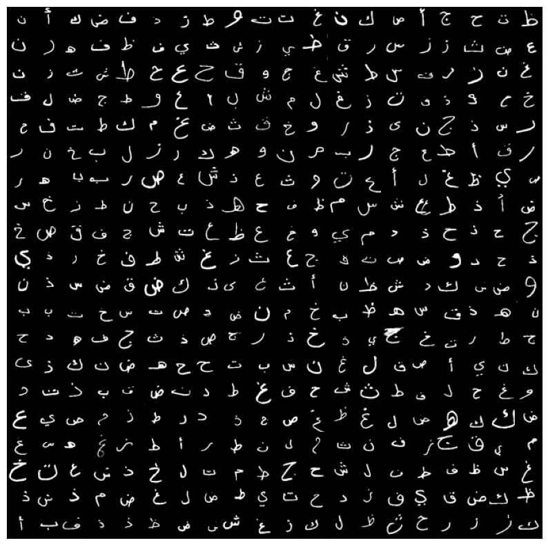

```python
plt.figure(figsize=(10, 10),)
for i in range(400):
    plt.subplot(20, 20, i + 1)
    plt.xticks([])
    plt.yticks([])
    plt.imshow(x_train[i], "gray")
plt.subplots_adjust(wspace=0.01, hspace=0.01)
plt.show()
```

Make the target label One-Versus-all (one hot encoding), in Arabic the characters are 28, so the resulting 28 column for each entry

```python
from tensorflow.keras.utils import to_categorical

y_train_A = to_categorical(y_train)
y_test_A  = to_categorical(y_test)
print(y_train_A.shape, y_test_A.shape)
```

```
(13440, 28) (3360, 28)
```

```python
y_train_A[0]
```

```
array([0., 0., 0., 0., 0., 0., 0., 0., 0., 0., 0., 0., 0., 0., 0., 0., 0.,
       0., 0., 0., 0., 0., 0., 0., 1., 0., 0., 0.])
```

```python
y_train_is_1 = y_train_A[:,0]

y_train_is_1
```

```
array([0., 1., 0., ..., 0., 0., 0.])
```

# Model Training and Testing

Define the models to train:

```python
from sklearn.linear_model import LogisticRegression, SGDClassifier
from sklearn.svm import LinearSVC, SVC
from sklearn.tree import DecisionTreeClassifier
from sklearn.ensemble import RandomForestClassifier
from sklearn.neighbors import KNeighborsClassifier
from sklearn.multiclass import OneVsRestClassifier

models = {
    "Logistic Regression": LogisticRegression(max_iter= 1000, random_state=42),
    "SVC": SVC(random_state=42, kernel='rbf'),
    "LinearSVC": LinearSVC(random_state=42, max_iter=1000),
    "Decision Tree": DecisionTreeClassifier( random_state=42),
    "Random Forest": RandomForestClassifier(random_state=42),
    "KNN": KNeighborsClassifier(weights='distance'),
    "SGD Classifier": SGDClassifier(max_iter=1000, random_state=42),
    "OVR Classifier": OneVsRestClassifier(SVC(random_state=42))

}
```

Evaluate each model using 28-fold cross-validation and store results:

```python
from sklearn.model_selection import StratifiedKFold,cross_val_score

n = 1500
X_flat = x_train[:n].reshape(-1, 32*32)
results = {}
cv = StratifiedKFold(n_splits=28, shuffle=True, random_state=42)
for model_name, model in models.items():
    print("-" * 70)
    print(f"Model: {model_name}")
    cv_scores = cross_val_score(model, X_flat, y_train[:n], cv=cv, scoring='accuracy')
    results[model_name] = {
        "model_name": model_name,
        "scores": cv_scores,
        "mean_accuracy": cv_scores.mean(),
    }
    print(f"{model_name} - Cross-Validation Accuracies: \n{cv_scores.round(4)}")
    print(f"- Max Accuracy: {cv_scores.max():.4f}")
    print(f"- Mean Accuracy: {cv_scores.mean():.4f}")
    print(f"- Min Accuracy: {cv_scores.min():.4f}")
    print("-" * 70)
```

```
----------------------------------------------------------------------
Model: Logistic Regression
Logistic Regression - Cross-Validation Accuracies:
[0.2222 0.2222 0.2222 0.2593 0.2222 0.3333 0.2963 0.1667 0.2593 0.3148
 0.2222 0.2778 0.4074 0.3333 0.3519 0.1667 0.2075 0.3019 0.3019 0.2642
 0.1887 0.283  0.3019 0.2264 0.2453 0.3019 0.283  0.3019]
- Max Accuracy: 0.4074
- Mean Accuracy: 0.2673
- Min Accuracy: 0.1667
----------------------------------------------------------------------
----------------------------------------------------------------------
Model: SVC
SVC - Cross-Validation Accuracies:
[0.3519 0.2963 0.3519 0.3519 0.2407 0.4444 0.4444 0.2407 0.3148 0.4444
 0.3333 0.2778 0.5    0.2963 0.4444 0.2963 0.3208 0.3396 0.3774 0.2642
 0.3585 0.3774 0.3962 0.3019 0.3208 0.3208 0.3962 0.3962]
- Max Accuracy: 0.5000
- Mean Accuracy: 0.3500
- Min Accuracy: 0.2407
----------------------------------------------------------------------
----------------------------------------------------------------------
Model: LinearSVC
LinearSVC - Cross-Validation Accuracies:
[0.2407 0.1296 0.2222 0.1667 0.1852 0.2963 0.2222 0.1296 0.2407 0.2222
 0.1852 0.2593 0.2407 0.2222 0.2963 0.1296 0.1132 0.1887 0.2075 0.2264
 0.1321 0.2264 0.2453 0.1887 0.1698 0.2642 0.2264 0.2453]
- Max Accuracy: 0.2963
- Mean Accuracy: 0.2080
- Min Accuracy: 0.1132
----------------------------------------------------------------------
----------------------------------------------------------------------
Model: Decision Tree
Decision Tree - Cross-Validation Accuracies:
[0.2407 0.1111 0.2407 0.1667 0.2222 0.2037 0.1481 0.2037 0.1481 0.2593
 0.1481 0.1481 0.1852 0.2037 0.2407 0.1481 0.1509 0.1509 0.3019 0.1509
 0.2075 0.1509 0.283  0.1509 0.1132 0.1321 0.2453 0.2453]
- Max Accuracy: 0.3019
- Mean Accuracy: 0.1893
- Min Accuracy: 0.1111
----------------------------------------------------------------------
```

[output cut: 25 more lines]

```
 0.1887 0.2075 0.1698 0.1698 0.1887 0.2264 0.2264 0.2453]
- Max Accuracy: 0.2963
- Mean Accuracy: 0.2134
- Min Accuracy: 0.1111
----------------------------------------------------------------------
----------------------------------------------------------------------
Model: OVR Classifier
OVR Classifier - Cross-Validation Accuracies:
[0.4074 0.4074 0.3704 0.3519 0.3889 0.4259 0.4074 0.2778 0.3519 0.4074
 0.2963 0.3704 0.5    0.3519 0.4444 0.2593 0.3962 0.3585 0.3585 0.3962
 0.4528 0.3962 0.3774 0.3774 0.3585 0.3585 0.4151 0.3962]
- Max Accuracy: 0.5000
- Mean Accuracy: 0.3807
- Min Accuracy: 0.2593
----------------------------------------------------------------------
```

See the best model that has the highest mean_accuracy:

```python
current_best_accuracy = 0
for model_name, result in results.items():
    if result["mean_accuracy"] > current_best_accuracy:
        current_best_accuracy = result["mean_accuracy"]
        best_model_name = model_name
        best_model = result["model_name"]

print(best_model_name, "with accuracy of", current_best_accuracy)
```

```
OVR Classifier with accuracy of 0.38071528401717075
```

Let us see if we can get a better results useing the Keras API:

```python
x_train = np.array([i.reshape(32, 32).T for i in TrainImages.to_numpy()]) / 255.0
x_test = np.array([i.reshape(32, 32).T for i in TestImages.to_numpy()]) / 255.0

y_test = TestLabels.to_numpy() - 1
y_train = TrainLabels.to_numpy() - 1

print("x_train.shape =", x_train.shape, "\ny_train.shape =", y_train.shape, "\nx_test.shape =", x_test.shape, "\ny_test.shape =", y_test.shape)
```

```
x_train.shape = (13440, 32, 32)
y_train.shape = (13440, 1)
x_test.shape = (3360, 32, 32)
y_test.shape = (3360, 1)
```

Define and build an CNN Sequential model:

```python
import tensorflow as tf
from tensorflow import keras
tf.random.set_seed(42)

model = None
model = keras.Sequential([
keras.layers.InputLayer(shape=(32, 32, 1)),

keras.layers.Conv2D(32, (3, 3), activation='relu', padding='same'),
keras.layers.MaxPooling2D((2, 2)),
keras.layers.BatchNormalization(),

keras.layers.Conv2D(64, (3, 3), activation='relu', padding='same'),
keras.layers.MaxPooling2D((2, 2)),
keras.layers.BatchNormalization(),

keras.layers.Conv2D(128, (3, 3), activation='relu', padding='same'),
keras.layers.MaxPooling2D((2, 2)),
keras.layers.BatchNormalization(),

keras.layers.Conv2D(256, (3, 3), activation='relu', padding='same'),
keras.layers.MaxPooling2D((2, 2)),
keras.layers.BatchNormalization(),

keras.layers.Flatten(),

keras.layers.Dense(256, activation="relu"),
keras.layers.Dropout(0.2),
keras.layers.BatchNormalization(),

keras.layers.Dense(128, activation="relu"),
keras.layers.Dropout(0.2),
keras.layers.BatchNormalization(),

keras.layers.Dense(64, activation="relu"),
keras.layers.Dropout(0.2),
keras.layers.BatchNormalization(),

keras.layers.Dense(32, activation="relu"),
keras.layers.Dropout(0.2),
keras.layers.BatchNormalization(),

keras.layers.Dense(28, activation="softmax")])

model.summary()
```

```
Model: "sequential"
```

```
┏━━━━━━━━━━━━━━━━━━━━━━━━━━━━━━━━━┳━━━━━━━━━━━━━━━━━━━━━━━━┳━━━━━━━━━━━━━━━┓
┃ Layer (type)                    ┃ Output Shape           ┃       Param # ┃
┡━━━━━━━━━━━━━━━━━━━━━━━━━━━━━━━━━╇━━━━━━━━━━━━━━━━━━━━━━━━╇━━━━━━━━━━━━━━━┩
│ conv2d (Conv2D)                 │ (None, 32, 32, 32)     │           320 │
├─────────────────────────────────┼────────────────────────┼───────────────┤
│ max_pooling2d (MaxPooling2D)    │ (None, 16, 16, 32)     │             0 │
├─────────────────────────────────┼────────────────────────┼───────────────┤
│ batch_normalization             │ (None, 16, 16, 32)     │           128 │
│ (BatchNormalization)            │                        │               │
├─────────────────────────────────┼────────────────────────┼───────────────┤
│ conv2d_1 (Conv2D)               │ (None, 16, 16, 64)     │        18,496 │
├─────────────────────────────────┼────────────────────────┼───────────────┤
│ max_pooling2d_1 (MaxPooling2D)  │ (None, 8, 8, 64)       │             0 │
├─────────────────────────────────┼────────────────────────┼───────────────┤
│ batch_normalization_1           │ (None, 8, 8, 64)       │           256 │
│ (BatchNormalization)            │                        │               │
├─────────────────────────────────┼────────────────────────┼───────────────┤
│ conv2d_2 (Conv2D)               │ (None, 8, 8, 128)      │        73,856 │
├─────────────────────────────────┼────────────────────────┼───────────────┤
│ max_pooling2d_2 (MaxPooling2D)  │ (None, 4, 4, 128)      │             0 │
├─────────────────────────────────┼────────────────────────┼───────────────┤
│ batch_normalization_2           │ (None, 4, 4, 128)      │           512 │
│ (BatchNormalization)            │                        │               │
├─────────────────────────────────┼────────────────────────┼───────────────┤
│ conv2d_3 (Conv2D)               │ (None, 4, 4, 256)      │       295,168 │
├─────────────────────────────────┼────────────────────────┼───────────────┤
│ max_pooling2d_3 (MaxPooling2D)  │ (None, 2, 2, 256)      │             0 │
├─────────────────────────────────┼────────────────────────┼───────────────┤
│ batch_normalization_3           │ (None, 2, 2, 256)      │         1,024 │
│ (BatchNormalization)            │                        │               │
├─────────────────────────────────┼────────────────────────┼───────────────┤
│ flatten (Flatten)               │ (None, 1024)           │             0 │
├─────────────────────────────────┼────────────────────────┼───────────────┤
│ dense (Dense)                   │ (None, 256)            │       262,400 │
├─────────────────────────────────┼────────────────────────┼───────────────┤
│ dropout (Dropout)               │ (None, 256)            │             0 │
├─────────────────────────────────┼────────────────────────┼───────────────┤
│ batch_normalization_4           │ (None, 256)            │         1,024 │
│ (BatchNormalization)            │                        │               │
├─────────────────────────────────┼────────────────────────┼───────────────┤
```

[output cut: 8 more lines]

```
├─────────────────────────────────┼────────────────────────┼───────────────┤
│ dropout_2 (Dropout)             │ (None, 64)             │             0 │
├─────────────────────────────────┼────────────────────────┼───────────────┤
│ batch_normalization_6           │ (None, 64)             │           256 │
│ (BatchNormalization)            │                        │               │
├─────────────────────────────────┼────────────────────────┼───────────────┤
│ dense_3 (Dense)                 │ (None, 32)             │         2,080 │
├─────────────────────────────────┼────────────────────────┼───────────────┤
│ dropout_3 (Dropout)             │ (None, 32)             │             0 │
├─────────────────────────────────┼────────────────────────┼───────────────┤
│ batch_normalization_7           │ (None, 32)             │           128 │
│ (BatchNormalization)            │                        │               │
├─────────────────────────────────┼────────────────────────┼───────────────┤
│ dense_4 (Dense)                 │ (None, 28)             │           924 │
└─────────────────────────────────┴────────────────────────┴───────────────┘
```

```
 Total params: 698,236 (2.66 MB)
```

```
 Trainable params: 696,316 (2.66 MB)
```

```
 Non-trainable params: 1,920 (7.50 KB)
```

Compile the model:

```python
model.compile(
	loss="sparse_categorical_crossentropy",optimizer=keras.optimizers.Adam(learning_rate=0.001),metrics=["accuracy"]
)
```

Define and Build a new file path to automatically store the best model after each 'epoch':

```python
checkpoint_filepath = 'best_model.keras'
model_checkpoint_callback = keras.callbacks.ModelCheckpoint(
    filepath=checkpoint_filepath, save_weights_only=False, monitor='val_accuracy', mode='max', save_best_only=True, verbose=1 )
```

Fit the model:

```python
history = model.fit(x_train, y_train, epochs=30, validation_split=0.2,
                    callbacks=[model_checkpoint_callback])
```

```
336/336 ━━━━━━━━━━━━━━━━━━━━ 0s 71ms/step - accuracy: 0.1352 - loss: 3.0797
Epoch 1: val_accuracy improved from -inf to 0.05357, saving model to best_model.keras
336/336 ━━━━━━━━━━━━━━━━━━━━ 37s 80ms/step - accuracy: 0.1354 - loss: 3.0784 - val_accuracy: 0.0536 - val_loss: 4.6100
336/336 ━━━━━━━━━━━━━━━━━━━━ 0s 73ms/step - accuracy: 0.4707 - loss: 1.6842
Epoch 2: val_accuracy improved from 0.05357 to 0.67857, saving model to best_model.keras
336/336 ━━━━━━━━━━━━━━━━━━━━ 27s 79ms/step - accuracy: 0.4709 - loss: 1.6836 - val_accuracy: 0.6786 - val_loss: 0.9920
336/336 ━━━━━━━━━━━━━━━━━━━━ 0s 83ms/step - accuracy: 0.6698 - loss: 1.0510
Epoch 3: val_accuracy improved from 0.67857 to 0.74033, saving model to best_model.keras
336/336 ━━━━━━━━━━━━━━━━━━━━ 30s 88ms/step - accuracy: 0.6698 - loss: 1.0507 - val_accuracy: 0.7403 - val_loss: 0.7553
336/336 ━━━━━━━━━━━━━━━━━━━━ 0s 74ms/step - accuracy: 0.7723 - loss: 0.7386
Epoch 4: val_accuracy improved from 0.74033 to 0.78720, saving model to best_model.keras
336/336 ━━━━━━━━━━━━━━━━━━━━ 27s 80ms/step - accuracy: 0.7724 - loss: 0.7385 - val_accuracy: 0.7872 - val_loss: 0.6405
336/336 ━━━━━━━━━━━━━━━━━━━━ 0s 74ms/step - accuracy: 0.8302 - loss: 0.5572
Epoch 5: val_accuracy improved from 0.78720 to 0.91183, saving model to best_model.keras
336/336 ━━━━━━━━━━━━━━━━━━━━ 27s 80ms/step - accuracy: 0.8302 - loss: 0.5571 - val_accuracy: 0.9118 - val_loss: 0.3182
336/336 ━━━━━━━━━━━━━━━━━━━━ 0s 80ms/step - accuracy: 0.8644 - loss: 0.4582
Epoch 6: val_accuracy did not improve from 0.91183
336/336 ━━━━━━━━━━━━━━━━━━━━ 29s 85ms/step - accuracy: 0.8644 - loss: 0.4582 - val_accuracy: 0.9107 - val_loss: 0.3055
336/336 ━━━━━━━━━━━━━━━━━━━━ 0s 75ms/step - accuracy: 0.8931 - loss: 0.3602
Epoch 7: val_accuracy did not improve from 0.91183
336/336 ━━━━━━━━━━━━━━━━━━━━ 27s 80ms/step - accuracy: 0.8931 - loss: 0.3602 - val_accuracy: 0.8464 - val_loss: 0.5243
336/336 ━━━━━━━━━━━━━━━━━━━━ 0s 76ms/step - accuracy: 0.9141 - loss: 0.3046
Epoch 8: val_accuracy did not improve from 0.91183
336/336 ━━━━━━━━━━━━━━━━━━━━ 41s 81ms/step - accuracy: 0.9141 - loss: 0.3045 - val_accuracy: 0.8181 - val_loss: 0.6062
336/336 ━━━━━━━━━━━━━━━━━━━━ 0s 76ms/step - accuracy: 0.9236 - loss: 0.2781
Epoch 9: val_accuracy did not improve from 0.91183
336/336 ━━━━━━━━━━━━━━━━━━━━ 28s 82ms/step - accuracy: 0.9236 - loss: 0.2780 - val_accuracy: 0.9059 - val_loss: 0.3605
336/336 ━━━━━━━━━━━━━━━━━━━━ 0s 87ms/step - accuracy: 0.9368 - loss: 0.2272
Epoch 10: val_accuracy improved from 0.91183 to 0.93601, saving model to best_model.keras
336/336 ━━━━━━━━━━━━━━━━━━━━ 31s 93ms/step - accuracy: 0.9368 - loss: 0.2272 - val_accuracy: 0.9360 - val_loss: 0.2513
336/336 ━━━━━━━━━━━━━━━━━━━━ 0s 79ms/step - accuracy: 0.9370 - loss: 0.2260
Epoch 11: val_accuracy did not improve from 0.93601
336/336 ━━━━━━━━━━━━━━━━━━━━ 29s 87ms/step - accuracy: 0.9370 - loss: 0.2260 - val_accuracy: 0.8973 - val_loss: 0.3386
336/336 ━━━━━━━━━━━━━━━━━━━━ 0s 79ms/step - accuracy: 0.9478 - loss: 0.1840
Epoch 12: val_accuracy did not improve from 0.93601
336/336 ━━━━━━━━━━━━━━━━━━━━ 40s 84ms/step - accuracy: 0.9478 - loss: 0.1839 - val_accuracy: 0.9222 - val_loss: 0.3098
336/336 ━━━━━━━━━━━━━━━━━━━━ 0s 77ms/step - accuracy: 0.9584 - loss: 0.1480
Epoch 13: val_accuracy did not improve from 0.93601
336/336 ━━━━━━━━━━━━━━━━━━━━ 41s 82ms/step - accuracy: 0.9584 - loss: 0.1480 - val_accuracy: 0.8806 - val_loss: 0.5309
336/336 ━━━━━━━━━━━━━━━━━━━━ 0s 78ms/step - accuracy: 0.9553 - loss: 0.1681
```

[output cut: 35 more lines]

```
336/336 ━━━━━━━━━━━━━━━━━━━━ 0s 79ms/step - accuracy: 0.9839 - loss: 0.0641
Epoch 26: val_accuracy did not improve from 0.94345
336/336 ━━━━━━━━━━━━━━━━━━━━ 28s 84ms/step - accuracy: 0.9839 - loss: 0.0641 - val_accuracy: 0.9074 - val_loss: 0.5479
336/336 ━━━━━━━━━━━━━━━━━━━━ 0s 84ms/step - accuracy: 0.9797 - loss: 0.0775
Epoch 27: val_accuracy did not improve from 0.94345
336/336 ━━━━━━━━━━━━━━━━━━━━ 30s 89ms/step - accuracy: 0.9797 - loss: 0.0775 - val_accuracy: 0.9286 - val_loss: 0.4127
336/336 ━━━━━━━━━━━━━━━━━━━━ 0s 81ms/step - accuracy: 0.9775 - loss: 0.0798
Epoch 28: val_accuracy improved from 0.94345 to 0.95685, saving model to best_model.keras
336/336 ━━━━━━━━━━━━━━━━━━━━ 29s 87ms/step - accuracy: 0.9775 - loss: 0.0798 - val_accuracy: 0.9568 - val_loss: 0.2511
336/336 ━━━━━━━━━━━━━━━━━━━━ 0s 78ms/step - accuracy: 0.9840 - loss: 0.0651
Epoch 29: val_accuracy did not improve from 0.95685
336/336 ━━━━━━━━━━━━━━━━━━━━ 29s 87ms/step - accuracy: 0.9840 - loss: 0.0651 - val_accuracy: 0.9427 - val_loss: 0.3253
336/336 ━━━━━━━━━━━━━━━━━━━━ 0s 79ms/step - accuracy: 0.9846 - loss: 0.0548
Epoch 30: val_accuracy did not improve from 0.95685
336/336 ━━━━━━━━━━━━━━━━━━━━ 40s 84ms/step - accuracy: 0.9846 - loss: 0.0549 - val_accuracy: 0.8936 - val_loss: 0.5470
```

Load and Evaluate the best model:

```python
best_model = keras.models.load_model(checkpoint_filepath)
score = best_model.evaluate(x_test, y_test)
print("Test loss:", score[0])
print("Test accuracy:", score[1])
```

```
105/105 ━━━━━━━━━━━━━━━━━━━━ 3s 20ms/step - accuracy: 0.9604 - loss: 0.2179
Test loss: 0.20965030789375305
Test accuracy: 0.961904764175415
```

[output not shown]

Visualize the Accuracy with Epoch:

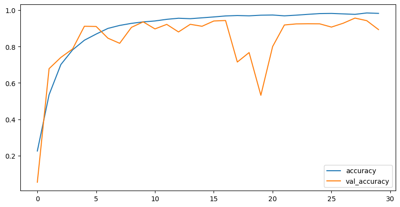

```python
plt.figure(figsize=(10,5))
plt.plot(history.history["accuracy"])
plt.plot(history.history["val_accuracy"])
plt.legend(["accuracy","val_accuracy"])
plt.show()
```

Visualize the Loss with Epoch:

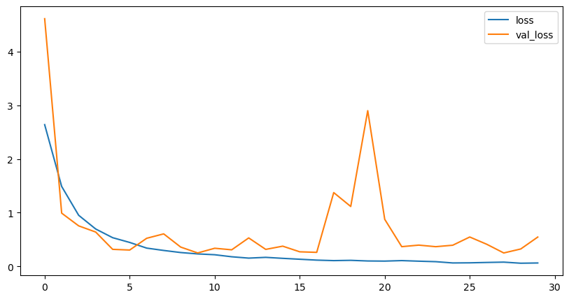

```python
plt.figure(figsize=(10,5))
plt.plot(history.history["loss"])
plt.plot(history.history["val_loss"])
plt.legend(["loss","val_loss"])
plt.show()
```

Use the model to predict:

```python
predictions_Test = best_model.predict(x_test)
predictions_Test = np.argmax(predictions_Test, axis=1)
predictions_Train = best_model.predict(x_train)
predictions_Train = np.argmax(predictions_Train, axis=1)
```

```
105/105 ━━━━━━━━━━━━━━━━━━━━ 2s 17ms/step
420/420 ━━━━━━━━━━━━━━━━━━━━ 7s 17ms/step
```

Plot the confusion matrix for both Train and Test sets:

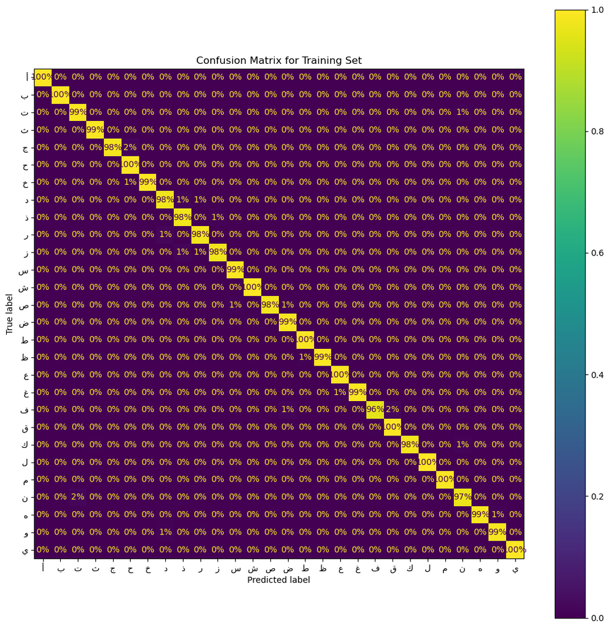

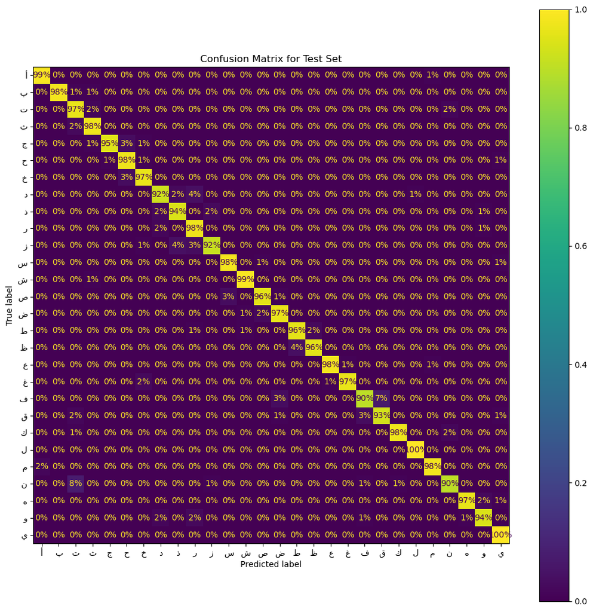

```python
from sklearn.metrics import ConfusionMatrixDisplay

classes = [numeric_arabic[x] for x in range(1, 29)]

plt.figure(figsize=(13, 13))
ConfusionMatrixDisplay.from_predictions(y_train, predictions_Train, display_labels=classes, normalize='true', values_format='.0%', ax=plt.gca())
plt.title("Confusion Matrix for Training Set")
plt.figure(figsize=(13, 13))
ConfusionMatrixDisplay.from_predictions(y_test, predictions_Test, display_labels=classes, normalize='true', values_format='.0%', ax=plt.gca())
plt.title("Confusion Matrix for Test Set")
plt.show()
```

See how the model behave: The wrong image predictions are colored with cmap="hot" to make the illustration better.

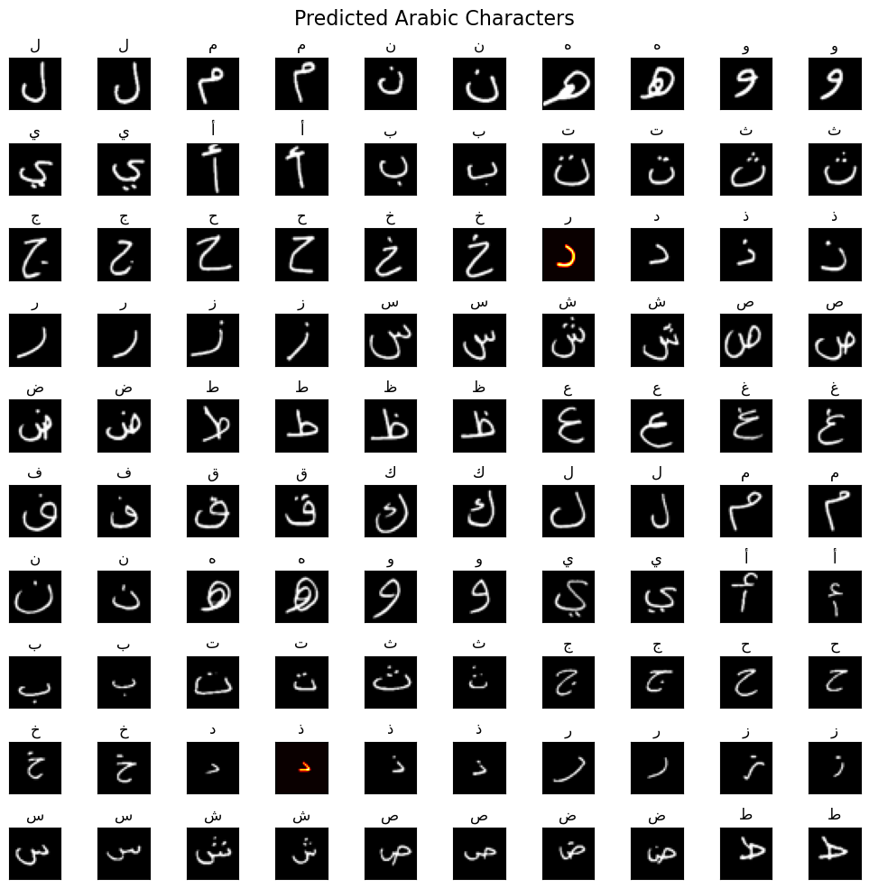

```python
n = 100
shift = 100
rows = int(np.ceil(np.sqrt(n)))
cols = int(np.ceil(n / rows))

plt.figure(figsize=(cols*1 , rows*1))
plt.suptitle('Predicted Arabic Characters', fontsize=16)

for i in range(n):
    plt.subplot(rows, cols, i+1)
    plt.xticks([])
    plt.yticks([])
    plt.title(numeric_arabic[predictions_Test[i+shift]+1], fontsize=12)
    if y_test[i+shift] != predictions_Test[i+shift]:
        plt.imshow(x_test[i+shift], cmap="hot")
    else:
        plt.imshow(x_test[i+shift], cmap="gray")
plt.tight_layout(rect=[0, 0, 1, 1])
plt.show() #10
```